# S1.5e: vuoti che tolgono cellule e vuoti allungati nella semina: tornano la densità del tessuto, i contatti e la forma degli spazi vuoti?

geo_spatialtrans, report di step (protocollo v2)

Published

October 27, 2026

# In breve

## In breve: se gli spazi vuoti del tessuto tolgono cellule invece di spingerle altrove, e hanno la forma allungata dei vuoti veri, la semina si avvicina ai tessuti veri?

**A cosa serviva.** Nello step precedente avevamo aggiunto alla semina delle cellule degli spazi vuoti dentro il tessuto, ma le cellule che vi sarebbero cadute venivano spinte nel resto del tessuto. Ne restavano due difetti: troppi nuclei a contatto nel tumore del colon e nello stroma del tumore, e vuoti tondeggianti dove quelli veri sono allungati (i lumi fra i villi dell’intestino di topo, la banda povera di cellule sotto la superficie del cervello di topo). Qui abbiamo provato tre varianti, ognuna calibrata sui tessuti veri: vuoti che tolgono le cellule; vuoti che tolgono le cellule e sono allungati; gli stessi con in più una densità che varia da zona a zona, con un tetto contro l’affollamento. Le abbiamo confrontate con la semina di oggi sugli stessi 300 tessuti simulati.

**Cosa abbiamo trovato**

1. **Un controllo di correttezza è fallito come era scritto, ma non rende inaffidabile nessun risultato.**
   - In un solo tessuto simulato dell’intestino, 6 cellule su 8 980 non hanno trovato posto (attese 0).
   - È lo stesso tessuto simulato dello step precedente, identico bit per bit, dove le 6 cellule mancavano già: la semina si ferma dopo troppi tentativi rifiutati di fila. Togliendolo non cambia nessun confronto.
   - Le varianti nuove non perdono nessuna cellula.
2. **Resta la semina di oggi: le varianti nuove riproducono 15 o 16 misure dei tessuti veri su 40, quella di oggi 19.**
   - I preset non cambiano; le varianti restano nel pacchetto come opzioni.
   - Il tetto alla densità risolve l’affollamento visto nello step precedente: nel caso che allora perdeva 533 cellule, con il tetto non se ne perde nessuna.
3. **I nuclei a contatto in eccesso non vengono da dove mettiamo le cellule, ma da come disegniamo il nucleo.**
   - Prima del calcolo abbiamo misurato i contatti a parità di distanza fra i centri: nel tumore del colon, con il vicino a meno di 5 µm, si toccano 96 nuclei simulati su 100 contro 47 su 100 fra i 17 nuclei veri giudicati a mano a quella distanza.
   - Togliere cellule non basta: nel tumore del colon i nuclei a contatto restano circa due su tre in ogni variante, contro al più 57 su 100 nei tessuti veri.
4. **Togliere cellule nei vuoti riporta la densità dell’intestino solo al limite basso del vero, e nel linfonodo e nel cervello la peggiora: lì la calibrazione mette vuoti che il tessuto non ha.**
   - Nell’intestino lo spazio vuoto è il 2 % delle finestre contate a mano e l’8 % del tessuto intero: il conteggio manuale misura la densità del tessuto pieno di cellule (circa 12 400 nuclei per mm²), più alta di quella del tessuto intero. Con i vuoti allungati la simulazione scende a circa 9 970, appena sotto il minimo dei tessuti veri (9 975).
   - Nel linfonodo i vuoti veri sono lo 0.2 % del tessuto, ma la calibrazione sceglie il 30 % di vuoti a strisce sottili, più strette della distanza fra due cellule. Così rende più irregolari le distanze fra vicini, che nelle simulazioni sono troppo regolari, ma toglie un terzo delle cellule: circa 19 000 nuclei per mm² contro almeno 21 500 nel vero. Nel cervello la densità scende a circa 800 contro almeno 900.
   - Anche nel cuore, che è nel pannello come controllo perché le sue cellule allungate non si prestano ai territori tondeggianti, la calibrazione ha scelto il 15 % di vuoti dove i veri sono meno dell’1 %. Con due sole ripetizioni le due scelte erano quasi pari: è rumore della calibrazione, non un segnale.
5. **I vuoti allungati prendono una forma più vicina al vero nel cervello, ma nell’intestino sono pochi e troppo allungati.**
   - Cervello: l’area vuota in vuoti molto allungati passa da un sesto a circa un quarto, contro almeno tre decimi nel vero.
   - Intestino: 43-48 vuoti per tessuto contro 96-117 veri, e più di metà dell’area vuota in vuoti molto allungati contro al più il 45 % nel vero. I lumi veri sono tanti, piccoli e ordinati fra i villi: un campo casuale non li produce.

**Cosa devi decidere**

1. **I tre controlli falliti come erano scritti bloccano lo step? Consiglio di no.**
   - Le 6 cellule non piazzate: spiegate sopra, già presenti nello step precedente.
   - Il cuore come controllo: la calibrazione doveva scegliere pochi vuoti e poco allungati, e non l’ha fatto; la differenza viene da una sola delle due ripetizioni, quindi è rumore.
   - Il controllo «i contatti seguono le distanze» era scritto sulla variante vincente, e ha vinto la semina di oggi: così confrontava la semina con sé stessa. È un errore di come lo avevamo scritto. Sulle varianti nuove tiene quasi ovunque (17 casi su 20), ma non nel linfonodo, dove i nuclei si toccano un poco più di quanto dicono le distanze (6-8 su 100).
   - Alternativa: considerarli bloccanti. Servirebbe ripetere la calibrazione del cuore con più ripetizioni (circa un’ora con 20 processori sul server del laboratorio) e rigiudicare; la scelta della semina non cambierebbe, perché resta quella di oggi.
2. **Le simulazioni con le zone dei tipi cellulari devono smettere di imporre il numero esatto di cellule di ogni tipo? Consiglio di sì, ma quando consolideremo il codice dello Step 1.**
   - Senza il numero imposto la semina riproduce un poco più misure dei tessuti veri (60 contro 58 sulla disposizione, 48 contro 46 per tipo): la regola scritta prima del calcolo dice di toglierlo.
   - Cambiarlo ora cambia i numeri casuali di ogni simulazione con le zone dei tipi e rompe i controlli che le confrontano bit per bit con gli step precedenti; al consolidamento rigeneriamo comunque tutto.
   - Alternative: cambiarlo subito (vanno riscritti quei controlli); oppure tenerlo (contro la regola, servirebbe una ragione).

**Comunque**

- Quando riprenderemo il disegno dei nuclei, misureremo i contatti a parità di distanza fra i centri: è lì il difetto, non nella semina.
- Quando rivedremo la densità dei preset, decideremo se il riferimento è il tessuto pieno di cellule (il conteggio a mano di oggi) o il tessuto intero con i suoi vuoti.
- Prima di usare i vuoti che tolgono cellule, la loro calibrazione dovrà avere anche la densità fra i bersagli, oppure vietare vuoti più stretti di una cellula; i lumi dell’intestino chiedono una forma costruita, non un campo casuale.
- Le varianti e il tetto alla densità restano nel pacchetto come opzioni, con i test.

Appena decidi questi 2 punti, lo step è chiuso.

**Sui tempi di calcolo.** La stima di 7-9 ore con 22 processori era mia, dai tempi dello step precedente, dove i vuoti grandi rallentavano la semina fino a quattro volte. Il calcolo è durato circa 4 ore e mezza con 20-22 processori, perché togliere cellule rende la semina più veloce. Dopo la revisione si sono aggiunti 12 minuti per la variante rifatta come era scritta (14 processori) e 72 minuti per ripetere test e controlli. La stima per ripetere la calibrazione del cuore (circa un’ora con 20 processori) è mia: le due varianti di vuoti hanno chiesto 6 720 semine in 59 minuti con 20 processori sui sei tessuti, cioè circa 10 minuti per il cuore con due ripetizioni; con dieci ripetizioni sono circa 50 minuti.

# Decisioni e verifiche di Luca

- «Approvo così» (previsioni, intervalli, regole A, B, Q, controprove CP-1…CP-3; 2026-10-26)
- «Quattro versioni dei vuoti, circa 7-9 ore» (perimetro del calcolo; 2026-10-26)
- «vanno bene i tuoi consigli» (decisione 1: G-3, CP-1, CP-2 e CP-3 falliti o vuoti come scritti non bloccano lo step; 2026-10-27, DEC-025)
- «vanno bene i tuoi consigli» (decisione 2: le quote per tipo si tolgono al consolidamento S1.6, BL-170; 2026-10-27, DEC-025)
- Lettura del riassunto «In breve» senza dubbi nuovi (2026-10-27). Step chiuso.
- Prossimo step: non ancora scelto da Luca; proposta e alternative nella sezione 7 di ROADMAP.

# Dubbi rinviati

Ogni voce è in `docs/BACKLOG.md` con cosa serve per chiuderla.

| voce | cosa | perché si rinvia | dove |
| --- | --- | --- | --- |
| BL-166 | contatti dei nuclei in eccesso a parità di distanza fra i centri (nel tumore del colon, vicino a meno di 5 µm: 0.96 simulato contro 0.47 manuale; E3, CP-3) | il difetto è nel disegno del nucleo, non nella semina: va affrontato dove si disegna il nucleo | da assegnare (modello del nucleo) |
| BL-167 | riferimento della densità: il conteggio manuale misura il tessuto pieno di cellule (spazio vuoto nelle finestre 0.022 contro 0.083 del ROI nell’intestino; E1) | scegliere il riferimento cambia i preset ed è una scelta sui riferimenti biologici, di Luca | revisione della densità dei preset (S1.6 o da assegnare) |
| BL-168 | calibrazione dei vuoti che tolgono cellule non identificata: nel linfonodo e nel cuore sceglie vuoti che il tessuto non ha (PH-1, RC-3); vuoti dell’intestino pochi e troppo allungati (P-16, P-17) | serve un bersaglio di densità o un asse corto minimo, e una forma costruita per i lumi; nessuna delle due cose è un aggiustamento di questo step | semina eterogenea, parte 4, o da assegnare |
| BL-169 | strumenti della calibrazione: bordi bassi della griglia non segnalati (RC-9), varianza della perdita delle pieghe con tutte le 5 ROI (RC-8), `void_grid_frac` pesata per punti della griglia (RC-6), ott… | non cambiano nessun verdetto di questo step | S1.6 (consolidamento) |
| BL-170 | applicare `quotas = FALSE` (regola Q di questo step) come comportamento della semina a compartimenti dei preset | cambia i numeri casuali e rompe i controlli bit per bit con gli step precedenti; S1.6 rigenera comunque il banco (DEC-025) | S1.6 (consolidamento) |

# Cancelli e regole

Pre-registrazione: commit `89c8579`; ok di Luca il 2026-10-26 sulle previsioni e sul perimetro del calcolo (commit `e932aae`). Codice e test al commit `7cbbb06`; calibrazioni e banco al commit `6bdadc4`; risultati prima della revisione al commit `14bb3a0`; correzioni della revisione (braccio XADs, test e mutanti nuovi, nessun taglio degli intervalli) nel commit di chiusura. Il dettaglio dei cinque cancelli è nella sezione «Dopo il risultato».

Bracci: U semina uniforme (predefinito); RV vuoti che spostano le cellule (S1.5d, nei preset come opzione); X vuoti tondi che tolgono cellule; XA vuoti allungati che tolgono cellule; XADs XA più una densità variabile con il tetto (come pre-registrato); XAD lo stesso con densità nulla ammessa (sensibilità, nota D-5); Q il vincente senza quote.

Regola A: modello dei vuoti (conferme in P-1, P-2, P-7, P-13, P-15, P-16, P-17; sens_XAD = XAD con densità nulla ammessa)

| winner | RV | X | XA | XADs | n_verdicts | counted | sens_XAD |
| --- | --- | --- | --- | --- | --- | --- | --- |
| RV | 19 | 15 | 15 | 16 | 40 | P-1, P-2, P-7, P-13, P-15, P-16, P-17 confermate | 16 |

Regola Q: quote per tipo sul vincente

| winner | spatial_quotas | spatial_noquotas | types_quotas | types_noquotas | result |
| --- | --- | --- | --- | --- | --- |
| RV | 58 | 60 | 46 | 48 | senza quote |

Regola B: predefinito dei preset

| final | reference | spatial_final | spatial_ref | size_final | size_ref | result |
| --- | --- | --- | --- | --- | --- | --- |
| RV | U | 58 | 19 | 19 | 21 | non adottata |

Conferme per previsione e braccio (spatial = P-1…P-7; size = P-8a, P-8b, P-8c; types = P-4, P-5, P-6; ruleA = insieme della regola A)

| arm | P-1 | P-2 | P-3 | P-4 | P-5 | P-6 | P-7 | P-8a | P-8b | P-8c | P-9 | P-10 | P-11 | P-12 | P-13 | P-14 | P-15 | P-16 | P-17 | spatial | size | types | ruleA |
| --- | --- | --- | --- | --- | --- | --- | --- | --- | --- | --- | --- | --- | --- | --- | --- | --- | --- | --- | --- | --- | --- | --- | --- |
| U | 2 | 0 | 3 | 6 | 4 | 4 | 0 | 6 | 14 | 1 | 6 | 6 | 1 | 0 | 0 | 10 | 4 | 1 | 2 | 19 | 21 | 14 | 9 |
| RV | 2 | 2 | 5 | 10 | 9 | 27 | 3 | 6 | 13 | 0 | 6 | 6 | 6 | 2 | 4 | 9 | 4 | 2 | 2 | 58 | 19 | 46 | 19 |
| X | 2 | 1 | 2 | 5 | 9 | 26 | 4 | 3 | 11 | 0 | 5 | 6 | 5 | 3 | 3 | 8 | 1 | 2 | 2 | 49 | 14 | 40 | 15 |
| XA | 2 | 1 | 1 | 2 | 8 | 26 | 4 | 4 | 12 | 0 | 5 | 6 | 5 | 3 | 3 | 8 | 0 | 3 | 2 | 44 | 16 | 36 | 15 |
| XAD | 2 | 1 | 1 | 4 | 8 | 26 | 4 | 4 | 12 | 0 | 5 | 6 | 5 | 4 | 4 | 8 | 0 | 3 | 2 | 46 | 16 | 38 | 16 |
| XADs | 2 | 1 | 1 | 4 | 9 | 24 | 4 | 4 | 10 | 0 | 5 | 6 | 5 | 3 | 5 | 8 | 0 | 3 | 1 | 45 | 14 | 37 | 16 |
| Q | 2 | 2 | 5 | 11 | 10 | 27 | 3 | 6 | 13 | 0 | 6 | 6 | 6 | 2 | 4 | 9 | 4 | 2 | 2 | 60 | 19 | 48 | 19 |

# Previsioni

Unità indipendente: ROI (valore della ROI = media dei 10 semi); stima = media delle 5 ROI ± 2 errori standard (P-15: 4 ROI con una finestra manuale); contatti: seme.

Previsioni per tessuto: stima ± 2 errori standard ed esito, quattro bracci (tutti i bracci e le misure per tipo in S1.5e_verdicts.csv)

| id | tessuto | unità | intervallo | RV (vincente) | esito | X | XA | XADs |
| --- | --- | --- | --- | --- | --- | --- | --- | --- |
| P-1 | intestino di topo | tessuto | 0.366-0.65 | 0.569 ± 0.024 | confermata | 0.4894 ± 0.024 confermata | 0.4484 ± 0.044 confermata | 0.4916 ± 0.025 confermata |
| P-1 | tumore del colon | tessuto | 0.217-0.567 | 0.6857 ± 0.044 | smentita | 0.6273 ± 0.03 smentita | 0.6245 ± 0.032 smentita | 0.6375 ± 0.04 smentita |
| P-1 | stroma del tumore | tessuto | 0.083-0.283 | 0.3595 ± 0.051 | smentita | 0.3077 ± 0.036 indeterminata | 0.3425 ± 0.042 smentita | 0.3319 ± 0.032 smentita |
| P-1 | linfonodo | tessuto | 0.35-0.75 | 0.8326 ± 0.019 | smentita | 0.781 ± 0.027 smentita | 0.7689 ± 0.028 indeterminata | 0.7352 ± 0.027 indeterminata |
| P-1 | cervello di topo | tessuto | 0-0.217 | 0.144 ± 0.016 | confermata | 0.1719 ± 0.016 confermata | 0.1295 ± 0.014 confermata | 0.1153 ± 0.023 confermata |
| P-1 | cuore | tessuto | 0-0.07 | 0.06979 ± 0.025 | indeterminata | 0.07615 ± 0.028 indeterminata | 0.07178 ± 0.021 indeterminata | 0.07129 ± 0.012 indeterminata |
| P-2 | intestino di topo | tessuto | -0.1-0.1 | 0.01675 ± 0.063 | confermata | -0.02507 ± 0.077 indeterminata | 0.06641 ± 0.073 indeterminata | 0.1074 ± 0.059 indeterminata |
| P-2 | tumore del colon | tessuto | -0.1-0.1 | -0.09926 ± 0.19 | indeterminata | -0.08862 ± 0.17 indeterminata | -0.1232 ± 0.18 indeterminata | -0.05339 ± 0.2 indeterminata |
| P-2 | stroma del tumore | tessuto | -0.1-0.1 | -0.1402 ± 0.19 | indeterminata | -0.1095 ± 0.19 indeterminata | -0.1451 ± 0.18 indeterminata | -0.09684 ± 0.2 indeterminata |
| P-2 | linfonodo | tessuto | -0.1-0.1 | -0.09862 ± 0.23 | indeterminata | 0.002115 ± 0.22 indeterminata | 0.08269 ± 0.28 indeterminata | 0.1615 ± 0.27 indeterminata |
| P-2 | cervello di topo | tessuto | -0.1-0.1 | 0.03632 ± 0.16 | indeterminata | 0.03697 ± 0.14 indeterminata | -0.1236 ± 0.13 indeterminata | -0.03654 ± 0.12 indeterminata |
| P-2 | cuore | tessuto | -0.1-0.1 | -0.02604 ± 0.068 | confermata | -0.02898 ± 0.052 confermata | -0.01965 ± 0.056 confermata | 0.006756 ± 0.083 confermata |
| P-3 | intestino di topo | tessuto | 0.2165-0.2309 | 0.2121 ± 0.00087 | smentita | 0.1632 ± 0.0012 smentita | 0.1731 ± 0.00086 smentita | 0.1772 ± 0.0011 smentita |
| P-3 | tumore del colon | tessuto | 0.3094-0.4334 | 0.3314 ± 0.0034 | confermata | 0.3056 ± 0.0069 indeterminata | 0.2978 ± 0.0093 smentita | 0.3021 ± 0.0089 indeterminata |
| P-3 | stroma del tumore | tessuto | 0.1166-0.3371 | 0.1318 ± 0.0014 | confermata | 0.1202 ± 0.0021 confermata | 0.1215 ± 0.0012 confermata | 0.1246 ± 0.00076 confermata |
| P-3 | linfonodo | tessuto | 0.4491-0.5013 | 0.4729 ± 0.0017 | confermata | 0.3949 ± 0.0004 smentita | 0.3906 ± 0.0066 smentita | 0.3934 ± 0.0076 smentita |
| P-3 | cervello di topo | tessuto | 0.08208-0.1108 | 0.1054 ± 0.003 | confermata | 0.0948 ± 0.0019 confermata | 0.08105 ± 0.0094 indeterminata | 0.0841 ± 0.0078 indeterminata |
| P-3 | cuore | tessuto | 0.02354-0.03659 | 0.02603 ± 0.00043 | confermata | 0.02216 ± 0.0027 indeterminata | 0.02276 ± 0.0013 indeterminata | 0.02318 ± 0.0018 indeterminata |
| P-7 | intestino di topo | tessuto | 0.3598-0.4516 | 0.2937 ± 0.00092 | smentita | 0.3096 ± 0.0021 smentita | 0.2917 ± 0.0024 smentita | 0.3258 ± 0.0031 smentita |
| P-7 | tumore del colon | tessuto | 0.421-0.6483 | 0.2854 ± 0.011 | smentita | 0.2799 ± 0.012 smentita | 0.2958 ± 0.016 smentita | 0.354 ± 0.032 smentita |
| P-7 | stroma del tumore | tessuto | 0.4611-0.791 | 0.5052 ± 0.0049 | confermata | 0.5098 ± 0.006 confermata | 0.5064 ± 0.005 confermata | 0.5454 ± 0.022 confermata |
| P-7 | linfonodo | tessuto | 0.1411-0.2412 | 0.111 ± 0.0056 | smentita | 0.1654 ± 0.00039 confermata | 0.1897 ± 0.0094 confermata | 0.2174 ± 0.0017 confermata |
| P-7 | cervello di topo | tessuto | 0.2908-0.6818 | 0.3157 ± 0.0088 | confermata | 0.3213 ± 0.015 confermata | 0.3235 ± 0.022 confermata | 0.3825 ± 0.016 confermata |
| P-7 | cuore | tessuto | 0.3088-0.3747 | 0.323 ± 0.0067 | confermata | 0.3186 ± 0.0058 confermata | 0.3226 ± 0.0033 confermata | 0.3387 ± 0.021 confermata |
| P-8a | intestino di topo | tessuto | 12.59-13.79 | 13.04 ± 0.015 | confermata | 13.44 ± 0.016 confermata | 13.36 ± 0.036 confermata | 13.3 ± 0.023 confermata |
| P-8a | tumore del colon | tessuto | 27.94-32.44 | 30.47 ± 0.11 | confermata | 32.14 ± 0.54 indeterminata | 32.64 ± 0.66 indeterminata | 32.29 ± 0.62 indeterminata |
| P-8a | stroma del tumore | tessuto | 27.79-33.79 | 32.99 ± 0.14 | confermata | 33.63 ± 0.18 indeterminata | 33.58 ± 0.14 confermata | 33.4 ± 0.16 confermata |
| P-8a | linfonodo | tessuto | 15.67-16.64 | 16.17 ± 0.041 | confermata | 18.8 ± 0.026 smentita | 18.98 ± 0.26 smentita | 18.87 ± 0.3 smentita |
| P-8a | cervello di topo | tessuto | 56.88-119.2 | 76.75 ± 1.2 | confermata | 79.65 ± 2.6 confermata | 84.34 ± 4.2 confermata | 84.59 ± 4.1 confermata |
| P-8a | cuore | tessuto | 17.54-31.71 | 21.8 ± 0.087 | confermata | 22.39 ± 0.35 confermata | 22.31 ± 0.28 confermata | 22.3 ± 0.22 confermata |
| P-8c | tumore del colon | tessuto | 0-0.0287 | 0.04347 ± 0.0028 | smentita | 0.03242 ± 0.0014 smentita | 0.03092 ± 0.0021 smentita | 0.03489 ± 0.0023 smentita |
| P-9 | intestino di topo | tessuto | -0.05-0.05 | 0.001041 ± 0.0056 | confermata | 0.00821 ± 0.0063 confermata | -0.003136 ± 0.0051 confermata | -0.001582 ± 0.005 confermata |
| P-9 | tumore del colon | tessuto | -0.05-0.05 | 0.02612 ± 0.0073 | confermata | 0.02614 ± 0.0089 confermata | 0.02672 ± 0.011 confermata | 0.02654 ± 0.011 confermata |
| P-9 | stroma del tumore | tessuto | -0.05-0.05 | 0.02496 ± 0.01 | confermata | 0.03001 ± 0.011 confermata | 0.02734 ± 0.0098 confermata | 0.02743 ± 0.01 confermata |
| P-9 | linfonodo | tessuto | -0.05-0.05 | 0.01153 ± 0.013 | confermata | 0.07328 ± 0.013 smentita | 0.05771 ± 0.016 indeterminata | 0.05614 ± 0.016 indeterminata |
| P-9 | cervello di topo | tessuto | -0.05-0.05 | 0.00342 ± 0.0095 | confermata | 0.01033 ± 0.0084 confermata | 0.004695 ± 0.0096 confermata | 0.006684 ± 0.011 confermata |
| P-9 | cuore | tessuto | -0.05-0.05 | -0.009442 ± 0.0099 | confermata | -0.01112 ± 0.0073 confermata | -0.007825 ± 0.0075 confermata | -0.003751 ± 0.0077 confermata |
| P-10 | intestino di topo | tessuto | 0-0.05 | 0.02801 ± 0.00057 | confermata | 0.01352 ± 0.0007 confermata | 0.01457 ± 0.00053 confermata | 0.01796 ± 0.00039 confermata |
| P-10 | tumore del colon | tessuto | 0-0.05 | 0.0367 ± 0.0026 | confermata | 0.02711 ± 0.0012 confermata | 0.02561 ± 0.0018 confermata | 0.02916 ± 0.0018 confermata |
| P-10 | stroma del tumore | tessuto | 0-0.05 | 0.007633 ± 0.00059 | confermata | 0.005888 ± 0.00034 confermata | 0.005939 ± 0.00048 confermata | 0.007384 ± 0.00081 confermata |
| P-10 | linfonodo | tessuto | 0-0.05 | 0.01682 ± 0.0006 | confermata | 0.005366 ± 0.00011 confermata | 0.004706 ± 0.00053 confermata | 0.00531 ± 0.00071 confermata |
| P-10 | cervello di topo | tessuto | 0-0.05 | 0.02127 ± 0.0017 | confermata | 0.01606 ± 0.0015 confermata | 0.009377 ± 0.0035 confermata | 0.01194 ± 0.0049 confermata |
| P-10 | cuore | tessuto | 0-0.05 | 0.01126 ± 0.0011 | confermata | 0.007586 ± 0.0023 confermata | 0.008923 ± 0.00093 confermata | 0.01033 ± 0.0019 confermata |
| P-11 | intestino di topo | tessuto | 0.06377-0.09429 | 0.07664 ± 0.0018 | confermata | 0.07134 ± 0.0038 confermata | 0.08263 ± 0.005 confermata | 0.08755 ± 0.0043 confermata |
| P-11 | tumore del colon | tessuto | 0.01647-0.07353 | 0.02752 ± 0.0053 | confermata | 0.03411 ± 0.0046 confermata | 0.02283 ± 0.0047 confermata | 0.02776 ± 0.005 confermata |
| P-11 | stroma del tumore | tessuto | 0.007647-0.1082 | 0.02988 ± 0.011 | confermata | 0.04185 ± 0.016 confermata | 0.02897 ± 0.0095 confermata | 0.03631 ± 0.011 confermata |
| P-11 | linfonodo | tessuto | 0-0.008228 | 0.002402 ± 0.002 | confermata | 7.053e-07 ± 9.5e-07 indeterminata | 0.0001013 ± 7.6e-05 confermata | 0.0001375 ± 6.8e-05 confermata |
| P-11 | cervello di topo | tessuto | 0.007523-0.1076 | 0.05394 ± 0.012 | confermata | 0.05395 ± 0.014 confermata | 0.02021 ± 0.029 indeterminata | 0.02958 ± 0.033 indeterminata |
| P-11 | cuore | tessuto | 0.003431-0.02 | 0.00752 ± 0.0039 | confermata | 0.007881 ± 0.0025 confermata | 0.008825 ± 0.0017 confermata | 0.01337 ± 0.0048 confermata |
| P-12 | intestino di topo | tessuto | 0.07209-0.1128 | 0.07136 ± 0.0028 | indeterminata | 0.07369 ± 0.0082 indeterminata | 0.09418 ± 0.0028 confermata | 0.1095 ± 0.0073 indeterminata |
| P-12 | tumore del colon | tessuto | 0.1029-0.3842 | 0.05524 ± 0.0069 | smentita | 0.05818 ± 0.0033 smentita | 0.05338 ± 0.0053 smentita | 0.09859 ± 0.022 indeterminata |
| P-12 | stroma del tumore | tessuto | 0.1942-1.073 | 0.2246 ± 0.024 | confermata | 0.2513 ± 0.034 confermata | 0.2319 ± 0.023 confermata | 0.2832 ± 0.04 confermata |
| P-12 | linfonodo | tessuto | 0.002369-0.04566 | -0.004236 ± 0.0021 | smentita | -0.008199 ± 0.00045 smentita | 0.001481 ± 0.0022 indeterminata | 0.01619 ± 0.0028 confermata |
| P-12 | cervello di topo | tessuto | 0.05342-0.4234 | 0.07635 ± 0.024 | indeterminata | 0.08093 ± 0.025 confermata | 0.02622 ± 0.096 indeterminata | 0.1024 ± 0.082 indeterminata |
| P-12 | cuore | tessuto | -0.01403-0.1305 | 0.01752 ± 0.0071 | confermata | 0.001562 ± 0.0092 confermata | 0.02121 ± 0.022 confermata | 0.03728 ± 0.034 confermata |
| P-13 | intestino di topo | tessuto | 0.04629-0.06037 | 0.05636 ± 0.0013 | confermata | 0.05419 ± 0.0015 confermata | 0.04435 ± 0.0012 smentita | 0.05062 ± 0.0015 confermata |
| P-13 | tumore del colon | tessuto | 0.02634-0.09758 | 0.0373 ± 0.0065 | confermata | 0.0308 ± 0.0053 indeterminata | 0.03281 ± 0.0048 confermata | 0.04313 ± 0.007 confermata |
| P-13 | stroma del tumore | tessuto | 0.05381-0.185 | 0.05435 ± 0.0081 | indeterminata | 0.06218 ± 0.0092 indeterminata | 0.05614 ± 0.0068 indeterminata | 0.06657 ± 0.012 confermata |
| P-13 | linfonodo | tessuto | 0.001315-0.01032 | 0.00503 ± 0.0015 | confermata | 0.001727 ± 0.00014 confermata | 0.004413 ± 0.0012 confermata | 0.007216 ± 0.00015 confermata |
| P-13 | cervello di topo | tessuto | 0.01226-0.05882 | 0.02994 ± 0.0056 | confermata | 0.03137 ± 0.0043 confermata | 0.01926 ± 0.019 indeterminata | 0.03074 ± 0.016 confermata |
| P-13 | cuore | tessuto | 0.009768-0.03073 | 0.01107 ± 0.0025 | indeterminata | 0.009574 ± 0.002 indeterminata | 0.01263 ± 0.0017 confermata | 0.01332 ± 0.0046 indeterminata |
| P-15 | intestino di topo | tessuto | 9975-1.152e+04 | 1.242e+04 ± 0.27 | smentita | 9325 ± 91 smentita | 9974 ± 72 indeterminata | 9929 ± 72 indeterminata |
| P-15 | tumore del colon | tessuto | 7476-1.003e+04 | 8924 ± 0.11 | confermata | 7811 ± 4.4e+02 indeterminata | 7592 ± 5.5e+02 indeterminata | 7593 ± 5.5e+02 indeterminata |
| P-15 | stroma del tumore | tessuto | 4328-9602 | 3100 ± 0.16 | smentita | 2747 ± 1.4e+02 smentita | 2819 ± 81 smentita | 2819 ± 81 smentita |
| P-15 | linfonodo | tessuto | 2.153e+04-3.075e+04 | 2.81e+04 ± 0.11 | confermata | 1.964e+04 ± 25 smentita | 1.893e+04 ± 8.1e+02 smentita | 1.893e+04 ± 8.1e+02 smentita |
| P-15 | cervello di topo | tessuto | 916.8-2275 | 1185 ± 0.31 | confermata | 1012 ± 17 confermata | 795.1 ± 54 smentita | 798.7 ± 53 smentita |
| P-15 | cuore | tessuto | 801-1102 | 988 ± 0.25 | confermata | 839.8 ± 1.3e+02 indeterminata | 838.5 ± 68 indeterminata | 838.1 ± 69 indeterminata |
| P-16 | intestino di topo | tessuto | 0.2294-0.4496 | 0.2102 ± 0.028 | indeterminata | 0.2183 ± 0.022 indeterminata | 0.5236 ± 0.037 smentita | 0.5479 ± 0.069 smentita |
| P-16 | tumore del colon | tessuto | 0.122-0.4537 | 0.2369 ± 0.018 | confermata | 0.1966 ± 0.052 confermata | 0.2764 ± 0.054 confermata | 0.2797 ± 0.041 confermata |
| P-16 | stroma del tumore | tessuto | 0.1878-0.3944 | 0.1591 ± 0.032 | indeterminata | 0.2027 ± 0.051 indeterminata | 0.2145 ± 0.026 confermata | 0.2395 ± 0.025 confermata |
| P-16 | cervello di topo | tessuto | 0.3045-0.967 | 0.1657 ± 0.059 | smentita | 0.1353 ± 0.057 smentita | 0.2827 ± 0.11 indeterminata | 0.2454 ± 0.1 indeterminata |
| P-16 | cuore | tessuto | 0.08909-0.3439 | 0.2271 ± 0.039 | confermata | 0.2311 ± 0.072 confermata | 0.2179 ± 0.06 confermata | 0.2882 ± 0.039 confermata |
| P-17 | intestino di topo | tessuto | 96-117 | 87.34 ± 7.8 | smentita | 83.76 ± 7.3 smentita | 43 ± 3 smentita | 47.82 ± 3.7 smentita |
| P-17 | tumore del colon | tessuto | 30-53 | 44.92 ± 12 | indeterminata | 30.44 ± 12 indeterminata | 34.9 ± 11 indeterminata | 40.86 ± 14 indeterminata |
| P-17 | stroma del tumore | tessuto | 21-62 | 34.54 ± 5.6 | confermata | 38.56 ± 4.8 confermata | 35.58 ± 4.7 confermata | 42.82 ± 4.4 confermata |
| P-17 | cervello di topo | tessuto | 2-17 | 15.02 ± 3.1 | indeterminata | 16.1 ± 3.5 indeterminata | 13.3 ± 8.3 indeterminata | 19.08 ± 7.6 indeterminata |
| P-17 | cuore | tessuto | 5-23 | 13.34 ± 5.2 | confermata | 11.68 ± 2.9 confermata | 13.3 ± 1.8 confermata | 19.14 ± 4.9 indeterminata |

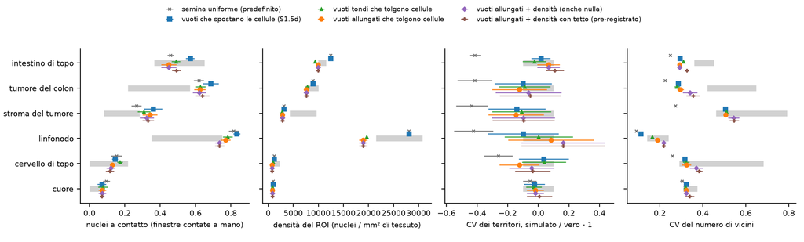

Misure di tessuto per braccio: nuclei a contatto, densità del ROI, variabilità dei territori (simulato / vero - 1), variabilità del numero di vicini. Bande grigie: intervallo di rilevanza pre-registrato (conteggio manuale per i contatti; minimo-massimo delle ROI vere con finestra manuale per la densità; ±0.10 per la variabilità dei territori; ROI vere per i vicini). Punti: stima ± 2 errori standard.

Cosa guardare: nel tumore del colon i contatti restano sopra la banda in tutti i bracci, anche togliendo cellule; la densità dell’intestino scende verso la banda solo con i vuoti che tolgono cellule, e nel linfonodo i bracci che tolgono cellule escono sotto la banda (nel cervello la scala non lo mostra: 795-799 contro almeno 917); a destra, nel linfonodo il numero di vicini entra nella banda solo togliendo cellule.

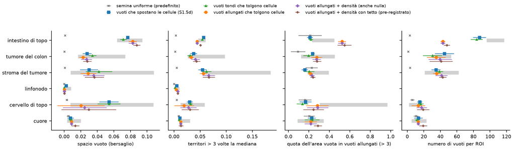

Spazio vuoto (bersaglio della calibrazione), territori più grandi di tre volte la mediana, quota dell’area vuota in vuoti molto allungati (allungamento > 3) e numero di vuoti per ROI, con l’intervallo fra ROI vere.

Cosa guardare: nel cervello i vuoti allungati salgono verso la banda; nell’intestino superano la banda per allungamento e restano sotto per numero (pochi vuoti grandi).

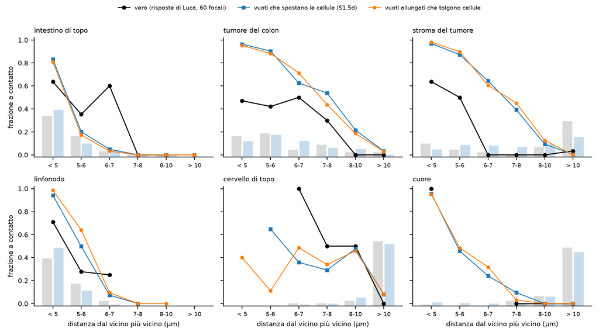

Contatto per classe di distanza dal vicino (E3 e D-desc-3): frazione di nuclei a contatto per classe, nei 60 nuclei focali giudicati a mano da Luca (nero), con i vuoti che spostano le cellule (blu) e con i vuoti allungati che tolgono cellule (arancione); barre: frazione dei focali in ogni classe (grigio vero, azzurro simulato).

Cosa guardare: nel tumore del colon, nello stroma e nel linfonodo, a pari distanza dal vicino, i nuclei simulati si toccano molto più dei veri; le due curve simulate quasi coincidono, quindi togliere cellule non cambia il modo in cui i nuclei si toccano a una data distanza. Nel cervello e nel cuore i focali veri vicini sono pochissimi e i punti neri non pesano.

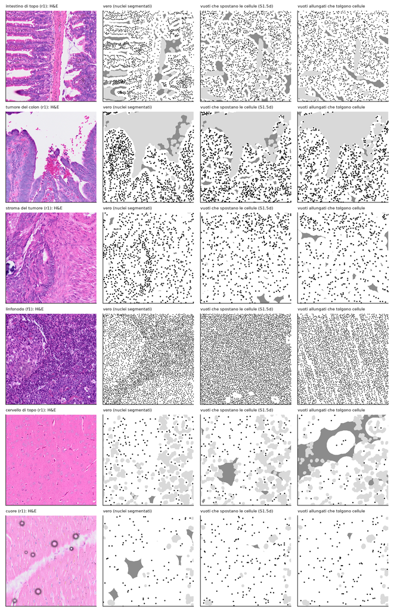

Un riquadro per tessuto (prima ROI): H&E, nuclei veri segmentati, vuoti che spostano le cellule (RV) e vuoti allungati che tolgono cellule (XA), seme 1; in grigio gli spazi vuoti.

Cosa guardare: nel linfonodo i vuoti allungati sono strisce sottili parallele senza cellule che nel tessuto vero non ci sono (PH-1).

# Dopo il risultato: cancelli, regole, controprove, post hoc e revisione avversariale

Scritto dopo il banco, le controprove, i cancelli ufficiali e la revisione avversariale; le correzioni chieste dalla revisione sono già applicate (note D-5 e D-6 sotto) e i cancelli sono stati rifatti dopo di esse. Ogni numero viene da un file di `results/S1.5e/` indicato accanto; il registro delle verifiche del riassunto è `results/S1.5e/S1.5e_verification_log.csv`.

### Note dopo la revisione (scritte dopo il banco; non cambiano previsioni né intervalli)

- **D-5, braccio XAD come pre-registrato (XADs).** Il testo pre-registrato definisce XAD come XA più una densità variabile (σ_d > 0). La calibrazione ammetteva anche σ_d = 0 fra i candidati e lo ha scelto in 18 pieghe su 36, così in 140 unità su 300 XAD coincideva con XA (revisione del codice, RC-1). Corretto: braccio **XADs** con σ_d > 0 obbligatorio, scelto fra le stesse semine di calibrazione già fatte (nessuna semina nuova), 300 unità nuove con gli stessi semi, giudicato al posto di XAD nella regola A. XAD (σ_d = 0 ammesso) resta riportato come sensibilità. Ottimi di XADs su tutte le ROI (`S1.5e_het_XADs.csv`): σ_d 0.3 in cinque tessuti (ℓ_d 10 µm in intestino e cuore, 80 µm in tumore del colon e cervello, 40 µm nello stroma) e 0.6 con ℓ_d 160 µm nel linfonodo; ℓ_d al bordo della griglia in cinque tessuti su sei. Semina del braccio: 9.6 min con 14 worker.
- **D-6, nessun taglio degli intervalli a [0, 1].** Lo script di analisi tagliava a [0, 1] gli intervalli delle frazioni (convenzione ereditata da S1.5d, non scritta nella pre-registrazione). Tolto: cambia un solo verdetto su 1 074, spazio vuoto H_rel_3 del linfonodo nel braccio X, da confermata a indeterminata (revisione numerica, RN-01; confronto con il commit `14bb3a0`: 1 riga diversa su 1 074). Nessuna regola cambia.

### Cancelli

| id | esito come scritto | dettaglio |
| --- | --- | --- |
| G-1 | PASS | `test_S1.5e.R` 16/16 (14 pre-registrate più T8c e T8d aggiunte dopo la revisione, sotto); regressioni con i soli FAIL ammessi: S1.5d 31/32 (T13), S1.5c 27/28 (T12), S1.5b 22/22, S1.5 81/83 (E10, E10b)… |
| G-2 | PASS (9/9 pre-registrati; 13/13 con i mutanti della revisione) | M1, M2, M4-M9 rilevati da asserzioni; M3 (allungamento ignorato) ferma la batteria, contato come rilevato secondo la regola di S1.5d. Dopo la revisione (RC-5) quattro mutanti nuovi: M10 fattore della … |
| G-3 | **FAIL come scritto** (6 cellule non piazzate, attese 0) | 2 100 unità (1 800 pre-registrate più le 300 di XADs) senza ERROR in C2, C3, C5, C9; U = U di S1.5d 300/300 e RV = RV di S1.5d 300/300 (md5); rerun di 8 unità identico; superamenti di lambda_max 0; md… |
| G-4 | PASS | forma dei vuoti con `skimage` uguale entro 1e-9 su 30 ROI vere e 30 unità di XA; forma dei vuoti veri uguale all’esplorazione E4 30/30; parametri della piega letti dal banco 30/30 per X, XA, XAD e XAD… |
| G-5 | PASS per il ricalcolo; discrepanze chiuse sotto | Revisione numerica: 16 942 controlli su 16 945 identici (entro 3.6e-12); i 1 074 verdetti, le regole A, Q, B e le controprove ricalcolati da zero; le 3 discrepanze sono il taglio a [0, 1] (D-6) e due … |

### Calibrazione

Semine: X e XA 6 720 in 58.7 min con 20 worker, estensione 770, XAD 2 700 più 150 dell’estensione della densità, 0 errori (`/mnt/micron/geo_spatialtrans/S1.5e/calpos_*.log`). Ottimi su tutte le ROI (`S1.5e_het_*.csv`): XA intestino φ 0.20, ℓ 32 µm, κ 4; tumore del colon 0.20, 16, 2; stroma 0.10, 32, 2; linfonodo 0.30, 8, 16 (κ al bordo dopo l’estensione); cervello 0.15, 32, 4; cuore 0.15, 16, 4. XAD (σ_d = 0 ammesso) aggiunge la densità solo in stroma (σ 0.3, ℓ 40) e linfonodo (0.6, 160, al bordo dopo l’estensione); XADs in tutti (D-5). Le pieghe lascia-fuori sono instabili nel cervello (φ da 0.10 a 0.35, ℓ da 8 a 64 µm) e nel linfonodo (φ 0.30-0.35).

### Regole

- **Regola A, modello dei vuoti**: RV 19, X 15, XA 15, XADs 16 conferme su 40 → **RV** (vuoti che spostano le cellule, S1.5d) (`S1.5e_ruleA.csv`). Sensibilità con XAD (σ_d = 0 ammesso): 16, stesso vincente. I preset non cambiano.
- **Regola Q, quote**: sul vincente, senza quote 60 conferme spaziali contro 58 e 48 per tipo contro 46 → **senza quote** (`S1.5e_ruleQ.csv`); applicazione al pacchetto: decisione di Luca (sotto, «In breve»). Con il braccio Q la revisione numerica ottiene lo stesso esito della regola B (RN-10).
- **Regola B, predefinito**: RV contro U, spaziali 58 contro 19, taglie 19 contro 21 → **non adottata** (`S1.5e_ruleB.csv`), come in S1.5d (stesse unità).

### Previsioni (vincente RV; accanto i bracci che tolgono cellule)

RV e U sono le stesse unità di S1.5d: i loro verdetti P-1…P-14 coincidono con quelli di S1.5d. Tabella completa in `S1.5e_verdicts.csv`, conteggi in `S1.5e_counts.csv`.

| id | atteso | osservato | esito rispetto all’atteso |
| --- | --- | --- | --- |
| P-1 contatti | tumore del colon e linfonodo smentite in ogni braccio | tumore del colon smentita in tutti i bracci (RV 0.686, X 0.627, XA 0.625, XAD 0.621, XADs 0.637; al più 0.567); linfonodo RV 0.833 smentita, XA 0.769, XAD e XADs 0.735 indeterminate; stroma RV 0.360 s… | come atteso nel tumore del colon; nel linfonodo i vuoti che tolgono cellule avvicinano i contatti al vero |
| P-15 densità del ROI | intestino confermata o indeterminata con XA; stroma smentita in tutti; gli altri confermati | intestino RV 12 419 smentita, X 9 325 smentita, XA 9 974 ± 72 indeterminata (minimo vero 9 975), XADs 9 929 indeterminata; stroma smentita in tutti; **linfonodo smentita con i vuoti che tolgono cellul… | peggio dell’atteso in linfonodo e cervello: la calibrazione mette lì molti vuoti (vedi PH-1) |
| P-16 vuoti allungati | XA confermata 5/5; RV smentita in intestino, stroma, cervello | XA 3/5: intestino **smentita per eccesso** (0.524, XADs 0.548; al più 0.450), cervello indeterminata (XA 0.283, XADs 0.245; RV 0.166 smentita; minimo vero 0.305), stroma confermata | peggio dell’atteso nell’intestino: vuoti troppo allungati |
| P-17 numero di vuoti | intestino confermata in XA | intestino XA 43, XADs 48 (vero 96-117) smentite, RV 87 smentita | peggio dell’atteso: pochi vuoti grandi |
| P-7 numero di vicini | come S1.5d | linfonodo confermata con i vuoti che tolgono cellule (X 0.165, XA 0.190, XAD e XADs 0.217; vero 0.141-0.241; RV 0.111 smentita); intestino e tumore del colon smentite in tutti | meglio dell’atteso nel linfonodo (vedi PH-1) |
| P-3 nucleo/territorio del tessuto | 5/6 | RV 5/6; bracci che tolgono cellule 1-2/6 (linfonodo 0.391-0.393 contro 0.449-0.501) | i territori più grandi abbassano il rapporto |
| P-8c cellule quasi senza citoplasma | smentita | RV 0.0435, X 0.0324, XA 0.0309, XAD 0.0340: tutte smentite (al più 0.0287) | come atteso |
| P-11 spazio vuoto | 6/6 | RV 6/6; X 5/6 (linfonodo indeterminata dopo D-6) |  |
| P-2, P-4, P-5, P-6, P-8a, P-8b, P-9, P-10, P-12…P-14 | come S1.5d | RV come S1.5d; i bracci che tolgono cellule confermano meno misure per tipo (P-4 2-5 contro 10) |  |

### Controprove

- **CP-1, cuore: fallita come scritta.** La calibrazione di XA su tutte le ROI del cuore sceglie φ 0.15 e κ 4 (richiesti al più 0.05 e 2). La parte appaiata (vincente meno RV) è nulla per costruzione, perché il vincente è RV. Spiegata come rumore della calibrazione (PH-1): con due repliche l’ottimo e il miglior punto con φ ≤ 0.05 sono quasi pari nella prima replica. I limiti 0.05 e 2 coincidono con i minimi della griglia, che lo strumento dei bordi non segnala (RC-9).
- **CP-2: fallita come scritta nel cuore** (κ 4; richiesto al più 2); tumore del colon κ 2, stroma κ 2, cervello κ 4: come atteso.
- **CP-3: non informativa come scritta.** Giudicata sul vincente, confronta RV con sé stesso (differenze 0 entro l’errore in 6/6). Errore di pre-registrazione: la controprova andava giudicata sui bracci che tolgono cellule. Su quei bracci (`S1.5e_cp.csv`, righe non giudicate): nel tumore del colon, nello stroma e nel cuore i contatti seguono le distanze in X, XA e XAD (differenze entro 2 errori standard; XADs nel tumore del colon +0.021 ± 0.015); nel linfonodo no (osservato sopra il previsto di 0.057-0.075 in tutti i bracci); intestino e cervello passano in XA, XAD e XADs, non in X. L’osservato della controprova è il contatto su tutte le finestre insieme, non la media a pesi uguali di P-1 (RN-07).

### Post hoc (dichiarati, dopo il banco)

- **PH-1, perché la calibrazione con i vuoti che tolgono cellule mette vuoti dove i veri non ci sono** (`tools/S1.5e_posthoc.py`, `S1.5e_posthoc_loss.csv`; perdita di tutte le ROI per bersaglio). **Linfonodo**: il miglior punto con φ ≤ 0.05 ha perdita 133.5, di cui 74.3 dalla variabilità della distanza dal vicino (distanze simulate troppo regolari, BL-068); l’ottimo (φ 0.30, κ 16) scende a 64.5 e quel termine a 9.4, con le due repliche concordi (68.0 e 61.8 contro 134.0 e 133.9). La revisione del codice (RC-3) ha indicato il meccanismo: con ℓ 8 µm e κ 16 l’asse corto del campo dei vuoti di XA nel linfonodo è ℓ / √κ = 2 µm, meno della distanza minima media fra centri (d̄ 4.00 µm, `review_codice/rev_identity_cap.log`), quindi i vuoti non fanno spazi vuoti ma diradano le cellule; le cellule per unità scendono da 27 998 (RV) a 19 022 (XA) (`S1.5e_panel_units.csv`). Il campo dei vuoti fa da sostituto di un meccanismo che manca (distanze irregolari) e toglie un terzo delle cellule: per questo la densità del linfonodo esce dal vero e il numero di vicini vi entra. Le mappe lo mostrano: strisce parallele senza cellule che nel tessuto non ci sono. **Cuore**: l’ottimo (φ 0.15, κ 4, perdita 39.5) e il miglior punto con φ ≤ 0.05 (κ 8, perdita 57.4) sono quasi pari nella prima replica (52.9 contro 55.0); la differenza viene dalla seconda (66.3 contro 165.0) e, per bersaglio, dall’allungamento (4.7 contro 24.5). Con due repliche la scelta nel cuore non è robusta: è rumore della calibrazione, non un segnale.
- **PH-2, instabilità fra pieghe**: vedi «Calibrazione».

### Descrittive

- D-desc-1 (BL-160): le quote rifiutano in RV dal 2.8 % (tumore del colon) all’11.0 % (linfonodo) delle proposte; senza quote 0.
- D-desc-1b: cellule tolte dai vuoti sul totale del piano: X da 0.12 (tumore del colon, stroma) a 0.30 (linfonodo); XA e XADs da 0.09 (stroma) a 0.32 (linfonodo), cervello 0.28.
- D-desc-3: contatto per classe di distanza (figura 3): a pari distanza i bracci che tolgono cellule si toccano quanto RV nel tumore del colon e nello stroma.
- D-desc-4: tempo mediano per unità da 8 s (stroma) a 44 s (intestino), simile fra bracci.
- D-desc-5: figura delle mappe nel report.
- La colonna `void_grid_frac` di `S1.5e_panel_units.csv` è una media pesata per il numero di punti della griglia delle regioni, non per l’area (RC-6): è solo descrittiva e non entra in nessun verdetto.

### Correzioni al testo pre-registrato (trovate dalla revisione numerica; non cambiano previsioni, intervalli né verdetti)

- Esplorazione E3: «7 602 contro 8 924 nuclei/mm² nelle finestre» usa denominatori diversi; sulla stessa area di tessuto il valore dei segmentatori è 7 702 (RN-04).
- Esplorazione E1, cuore: 988 è la densità manuale del preset (B-048), non la media delle finestre (968.1) (RN-05).
- Esplorazione E3, contatto controfattuale: è rinormalizzato sulle classi di distanza presenti (cervello RV 0.138 contro 0.133 senza rinormalizzare) (RN-08).
- Intervalli di P-1 arrotondati a 3 decimali nella pre-registrazione: si giudicano come scritti. Con il limite esatto dello stroma (0.2833) XAD nello stroma passerebbe da smentita a indeterminata (RN-06); nessuna regola cambia.

### Revisione avversariale e come è stata chiusa

Due revisori indipendenti, senza il contesto della sessione: uno ha ricalcolato i numeri da zero (`/mnt/micron/geo_spatialtrans/S1.5e/review_num/`), l’altro ha letto il codice e scritto mutanti (`/mnt/micron/geo_spatialtrans/S1.5e/review_codice/`).

| voce | cosa | come è chiusa |
| --- | --- | --- |
| RN-01 | taglio non scritto degli intervalli a [0, 1]; spazio vuoto del linfonodo in X «confermata» invece di «indeterminata» | corretto (D-6); 1 verdetto su 1 074 cambia, nessuna regola |
| RN-02, RC-2 | CP-1 appaiata e CP-3 vuote per costruzione quando vince RV | errore di pre-registrazione, scritto in «Controprove»; CP-3 sui bracci che tolgono cellule riportata (fallisce nel linfonodo) |
| RN-03 | CP-1 e CP-2 falliscono nel cuore | scritto; spiegato come rumore della calibrazione (PH-1); decisione di Luca |
| RN-04, RN-05, RN-08 | numeri del testo dell’esplorazione | «Correzioni al testo pre-registrato» |
| RN-06 | intervalli di P-1 arrotondati | giudicati come scritti; effetto dichiarato |
| RN-07 | osservato di CP-3 su tutte le finestre insieme | dichiarato in «Controprove» |
| RN-09 | togliere l’unità con 6 cellule non piazzate non cambia nulla | riportato in G-3 |
| RN-10 | regola B con Q: non adottata | riportato in «Regole» |
| RC-1 | σ_d = 0 ammesso in XAD, non pre-registrato | corretto (D-5, braccio XADs); regola A invariata |
| RC-3 | nel linfonodo i vuoti sono più stretti della distanza minima e diradano le cellule | spiegazione aggiunta a PH-1; rinviato: calibrazione dei vuoti che tolgono cellule (BACKLOG) |
| RC-4 | il tetto limita il fattore, non la densità locale (nel linfonodo p2 di XAD la densità locale supera il tetto al più di 1.061 volte, sul 21 % dell’area, per i compartimenti); d̄ è una media pesata (4.0… | documentazione corretta in `R/04b2_seed_centroids.R`; il riscalamento è necessario: senza, la media del fattore sarebbe 0.772 e la densità locale fino a 1.28 volte il tetto (`review_codice/rev_identit… |
| RC-5 | mutanti MA-MD non rilevati | test T8c e T8d aggiunti; mutanti M10-M13 rilevati 4/4 (G-2) |
| RC-6 | `void_grid_frac` pesata per punti della griglia | dichiarato in «Descrittive»; rinviato (BACKLOG) |
| RC-7 | `quotas = FALSE` della regola Q non applicato nel pacchetto | decisione di Luca |
| RC-8 | varianza della perdita delle pieghe con tutte le 5 ROI vere (da S1.5d) | dichiarato; rinviato con gli strumenti della calibrazione (BACKLOG) |
| RC-9 | i bordi bassi della griglia di φ_v e κ non sono segnalati; i limiti di CP-1 sono i minimi della griglia | dichiarato in «Controprove»; rinviato (BACKLOG) |
| RC-10 | T11 e G-4 b non controllavano ℓ_d e il tetto | estesi; PASS (G-1, G-4) |

# Cosa è girato

- Banco: 2 100 unità (30 ROI × 10 semi × 7 bracci, compreso XADs dopo la revisione), seme = 20261021 + 1000 · i + s come S1.5c e S1.5d, su lesexp-server con 14-22 worker a un thread.
- Calibrazioni: X e XA 6 720 semine più 770 di estensione, XAD 2 700 più 150, 0 errori; seme 20261026 + 1000 · i + r; pieghe lascia-fuori-una-ROI.
- md5 dei 93 file letti prima e dopo: identici.
- Tempo: circa 4 ore e mezza di calcolo con 20-22 worker prima della revisione; dopo la revisione 12 minuti per XADs (14 worker) e 72 minuti per test, mutanti e controlli.

Tempo mediano di place_cells() per unità (s)

| archetype | est.U | est.RV | est.X | est.XA | est.XAD | est.XADs | est.Q |
| --- | --- | --- | --- | --- | --- | --- | --- |
| A1 | 30.5 | 43.9 | 35.8 | 36.4 | 33.7 | 38.3 | 39.2 |
| A2 | 18.3 | 20.8 | 18.4 | 17.3 | 19.9 | 19.7 | 19.0 |
| A3 | 3.8 | 9.1 | 8.3 | 8.5 | 9.1 | 9.0 | 6.7 |
| A4 | 31.9 | 41.8 | 29.5 | 26.8 | 27.2 | 26.3 | 33.3 |
| A5 | 16.6 | 24.8 | 23.3 | 19.1 | 20.5 | 22.0 | 22.1 |
| A6 | 8.1 | 12.1 | 12.2 | 10.8 | 9.0 | 13.2 | 9.7 |

# Appendice

## Dubbi ricevuti

| voce | cosa | in S1.5e |
| --- | --- | --- |
| BL-162 | con i vuoti le cellule tolte si addensano altrove: contatti 0.686 nel tumore del colon (manuale al più 0.567) e 0.360 nello stroma (al più 0.283); eccesso di CV² a 50 µm smentito nel tumore del colon … | (1) vuoti che tolgono cellule (braccio X); (2) vuoti allungati (bracci XA, XAD); (3) densità variabile solo fuori dai vuoti (braccio XAD). L’esplorazione sotto mostra che l’eccesso di contatti non vie… |
| BL-160 | le quote per tipo rifiutano dal 2.8 % all’11.0 % delle proposte; senza quote 60 conferme spaziali contro 58 | braccio Q sul vincente e regola Q scritta prima |
| BL-164 | saturazione della densità (linfonodo, bracci con densità variabile) e ottimi al bordo della griglia | griglie dei vuoti più ampie (φ_v fino a 0.35, allungamento); tetto della densità locale nel braccio XAD. I bordi della griglia dei compartimenti per tipo (s = 8, ℓ = 1024 µm) restano fuori: richiedono… |

Fuori da S1.5e, dichiarato: BL-158 (modello di taglia con dispersione che cresce col territorio), BL-163, BL-165, BL-161 restano ai loro step.

## Esplorazione prima della pre-registrazione

Solo dati veri e unità già simulate di S1.5d (bracci U, N, RV, VF), nessuna simulazione nuova[^explore][^explorec]. Strumenti `tools/S1.5e_explore.py` e `tools/S1.5e_explore_contacts.py`.

**E1. La densità di riferimento è misurata in finestre con pochi vuoti.** Le 24 finestre di R2b sono state poste a caso nei ROI e accettate solo con almeno il 90 % di tessuto valido (`tools/R2b_windows.py`). Frazione dei pixel della maschera lontani dal nucleo segmentato più vicino più di 3 distanze mediane dal vicino (la stessa misura dello spazio vuoto di S1.5d), media delle 4 finestre contro media dei 4 ROI che le contengono:

| tessuto | vuoti nelle finestre | vuoti nei ROI | densità del ROI stimata (nuclei/mm²) | preset (conteggio manuale) |
| --- | --- | --- | --- | --- |
| intestino | 0.022 | 0.083 | 10 503 (9 975-11 522) | 12 419 |
| tumore del colon | 0.003 | 0.033 | 8 808 (7 476-10 026) | 8 924 |
| stroma | 0.107 | 0.035 | 5 974 (4 328-9 602) | 3 100 |
| linfonodo | 0.000 | 0.002 | 27 644 (21 533-30 746) | 28 096 |
| cervello | 0.003 | 0.040 | 1 338 (917-2 275) | 1 185 |
| cuore | 0.001 | 0.007 | 982 (801-1 102) | 988 |

Densità del ROI stimata = densità dei nuclei segmentati nel ROI intero × (punti manuali / nuclei segmentati nella finestra del ROI); tra parentesi minimo e massimo dei 4 ROI. Lettura: in intestino, tumore del colon e cervello le finestre contate a mano contengono da un quarto a un decimo dei vuoti del ROI; il conteggio manuale è quindi una densità del tessuto cellulare, e con la regola attuale (il numero di cellule del ROI = densità manuale × area con i vuoti) l’intestino simulato ha 12 419 nuclei/mm² contro circa 10 500 stimati. Nello stroma è il contrario: una finestra su quattro (A3_w4) cade in un grande vuoto (0.415) e la densità manuale dello stroma è più bassa di quella del ROI stimata.

**E2. L’affollamento dei centri con i vuoti di S1.5d è già quello dei punti manuali.** Vicini entro 8 µm dei focali (a 15 µm dai lati della finestra), media delle 4 finestre: intestino manuale 2.89, RV 2.85, N 2.22; tumore del colon manuale 1.57, RV 1.64, N 1.34; stroma manuale 0.59, RV 0.66; linfonodo manuale 4.91, RV 4.83. Distanza mediana dal vicino nel tumore del colon: manuale 5.95 µm, RV 6.09, N 6.41.

**E3. L’eccesso di contatti viene dal modello del nucleo, non dalla semina.** Per i 60 focali di R2c per tessuto: distanza dal vicino fra i punti manuali e contatto dalle risposte di Luca (variante primaria; ricostruzione uguale a `R2c_s1.csv` in 6 tessuti su 6). Per i focali simulati: stessa regola dei focali di S1.5d e contatto del raster. A pari distanza dal vicino i nuclei simulati si toccano molto più spesso: nel tumore del colon, sotto 5 µm, 0.96 (RV) contro 0.47 (manuale, 17 focali); fra 5 e 6 µm 0.90 contro 0.42 (19 focali). Contatti che il modello del nucleo darebbe con le distanze vere (frazioni per classe di distanza del manuale × contatto simulato per classe):

| tessuto | manuale | N | RV | U |
| --- | --- | --- | --- | --- |
| intestino | 0.500 | 0.516 | 0.519 | 0.495 |
| tumore del colon | 0.367 | 0.701 | 0.728 | 0.682 |
| stroma | 0.183 | 0.350 | 0.335 | 0.327 |
| linfonodo | 0.550 | 0.746 | 0.751 | 0.729 |
| cervello | 0.083 | 0.157 | 0.123 | 0.138 |
| cuore | 0.017 | 0.024 | 0.023 | 0.020 |

Lettura: nel tumore del colon, nello stroma e nel linfonodo togliere cellule abbasserebbe i contatti solo perché allontana i centri; il difetto (a pari distanza i nuclei simulati si toccano circa il doppio) resta. Il modello del nucleo era stato confermato sui centri dei segmentatori (R2c, S1.4d), che nel tumore del colon sono più radi dei punti manuali (7 602 contro 8 924 nuclei/mm² nelle finestre). Questo diventa una voce di BACKLOG per il modello del nucleo, fuori da S1.5e.

**E4. I vuoti veri sono più allungati dei simulati nel cervello e nell’intestino.** Componenti connesse dei pixel vuoti (stessa soglia di 3 distanze mediane, almeno 50 µm²), allungamento = radice del rapporto degli autovalori dei momenti, mediana pesata per area; media dei 5 ROI (RV: 3 semi per ROI):

| tessuto | allungamento vero (min-max ROI) | RV | quota dell’area vuota in componenti con allungamento > 3, vero (min-max) | RV | componenti per ROI, vero (min-max) | RV |
| --- | --- | --- | --- | --- | --- | --- |
| intestino | 2.59 (2.06-3.00) | 2.09 | 0.36 (0.23-0.45) | 0.20 | 105 (96-117) | 89 |
| tumore del colon | 2.25 (1.78-2.76) | 2.19 | 0.26 (0.12-0.45) | 0.26 | 36 (30-53) | 41 |
| stroma | 2.27 (1.96-2.48) | 2.03 | 0.26 (0.19-0.39) | 0.15 | 35 (21-62) | 33 |
| linfonodo | (0-3 componenti per ROI) |  |  |  |  |  |
| cervello | 5.24 (2.32-6.97) | 1.85 | 0.76 (0.31-0.97) | 0.12 | 7 (2-17) | 14 |
| cuore | 2.39 (1.94-2.98) | 2.19 | 0.20 (0.09-0.34) | 0.24 | 14 (5-23) | 15 |

Nel cervello 4 ROI su 5 hanno pochi vuoti grandi (spessore 84-126 µm), molto allungati e orientati (coerenza dell’orientamento 0.93-0.99): la banda povera di cellule sotto la superficie (strato 1). Nel tumore del colon, nello stroma e nel cuore i vuoti simulati sono già allungati come i veri.

Conseguenze per il disegno: (1) togliere cellule è giustificato dal riferimento della densità (E1), non dai contatti; (2) la previsione sui contatti di tumore del colon, stroma e linfonodo è «smentita» in ogni braccio (E3); (3) i vuoti allungati servono soprattutto al cervello e all’intestino (E4); (4) nello stroma il riferimento della densità ha il problema opposto (E1), quindi togliere cellule lì peggiora la densità: lo si scrive come previsione.

## Pre-registrazione (testo del file dello step)

Commit dei cancelli e delle previsioni: `89c8579`. Ok di Luca su previsioni, intervalli, regole A, B, Q e controprove: 2026-10-26, in chat, alla domanda «Approvi le previsioni con i loro intervalli, le tre regole (modello dei vuoti, quote, predefinito) e le tre controprove come scritte sopra e nel file dello step?»: «Approvo così». Alla domanda sul calcolo («Quanto calcolo facciamo?») Luca ha scelto «Quattro versioni dei vuoti, circa 7-9 ore».

### Cosa si implementa (scritto prima del codice)

In `R/04b2_seed_centroids.R`, tabella `heterogeneity` (S1.5d) con tre colonne opzionali; se assenti o ai valori neutri, comportamento di S1.5d bit per bit, nessuna estrazione casuale in più:

1. `void_mode` = `"move"` (S1.5d) o `"remove"`: con `"remove"` il numero di cellule della regione è quello del piano moltiplicato per (1 - v), con v = frazione dei punti della griglia della regione dentro un vuoto; per tipo n_t’ = floor(n_t (1 - v)) + Bernoulli(resto), così il valore atteso è esatto; le quote usano n_t’. La densità del preset vale quindi nella parte non vuota.
2. `void_aspect` κ ≥ 1 (1 = S1.5d): campo dei vuoti anisotropo, lunghezze di correlazione ℓ_v √κ lungo un asse e ℓ_v / √κ lungo l’altro (frequenze di Fourier ω = R(θ) diag(1 / (ℓ_v √κ), √κ / ℓ_v) z, z ~ N(0, I)); orientamento θ ~ U(0, π) estratto una volta per regione, solo se κ > 1.
3. `dens_cap` (solo con un campo della densità): il fattore exp(σ_d W) è troncato a h_max = λ_cap / λ̄, con λ̄ = cellule della regione / area non vuota e λ_cap = 0.8 × 0.547 / (π d*² / 4) (80 % della densità di saturazione della semina sequenziale casuale di dischi di diametro d*, la distanza minima del tessuto; BL-164).

`tissue_preset_spec()` e `place_cells()`: le stesse colonne nella tabella `heterogeneity` del preset e in `override_heterogeneity`. I preset non cambiano salvo la regola A.

**Calibrazione dei vuoti** (`tools/S1.5e_calibration_pos.R` e `.py`, da quelli di S1.5d): stesso modello, stesse 30 maschere, compartimenti e distanza per nucleo come in S1.5d (DEC-020, DEC-022), 2 repliche, semi 20261026 + 1000 · i + r (diversi dal banco e da S1.5d). Bersagli: gli 8 di S1.5d (spazio vuoto a 1.5, 2, 3, 4 distanze; CV² in eccesso a 25, 50, 100 µm; CV della distanza dal vicino) più l’allungamento dei vuoti (E4), con la stessa perdita (scarto² / varianza fra le 5 ROI vere del bersaglio). Griglie: **X** (togliere, isotropo) φ_v ∈ {0.05, 0.10, …, 0.35} × ℓ_v ∈ {8, 16, 32, 64} µm (28); **XA** (togliere, allungati) le stesse × κ ∈ {2, 4, 8} (84); **XAD** (XA + densità) con i vuoti dell’ottimo di XA nella stessa piega, σ_d ∈ {0.3, 0.6, 0.9} × ℓ_d ∈ {10, 40, 80} µm e il tetto (9). Pieghe lascia-fuori-un-ROI e tutte le ROI; un’estensione della griglia di un passo se l’ottimo di tutte le ROI sta al bordo (come S1.5d). Nel linfonodo l’allungamento non entra nella perdita (0-3 componenti vere per ROI).

**Banco** `tools/S1.5e_bench.R`, come S1.5d: 30 ROI × 10 semi, seme = 20261021 + 1000 · i + s (gli stessi di S1.5d, quindi U e RV appaiati e identici), parametri della piega della ROI simulata, uscite in `/mnt/micron/geo_spatialtrans/S1.5e/`, un file per unità, rilanciabile, worker dal file `WORKERS` (al più 22) con la guardia termica di MMM. Bracci (1 800 unità):

| braccio | vuoti | cellule nei vuoti | densità | ruolo |
| --- | --- | --- | --- | --- |
| U |  |  |  | semina uniforme, riferimento del predefinito (= U di S1.5d, md5) |
| RV | isotropi (S1.5d) | spostate |  | riferimento (= RV di S1.5d, md5) |
| X | isotropi, ricalibrati | tolte |  | candidato |
| XA | allungati | tolte |  | candidato |
| XAD | allungati (di XA) | tolte | sì, con tetto | candidato |
| Q | vincente della regola A | come il vincente | come il vincente | `quotas = FALSE` (BL-160), generato dopo la regola A |

Tutti i bracci a compartimenti: compartimenti ricalibrati di S1.5d (B-232…B-248), distanza per nucleo, modello di taglia gaussiano del gruppo (DEC-022).

**Metriche**: quelle di S1.5d (stesse funzioni), più la densità del ROI (cellule / area della maschera) e la forma dei vuoti (`tools/S1.5e_metrics.py`, stessa funzione per vero e simulato).

### Scelte decise dai dati (regole scritte prima del banco)

- **Regola A, modello dei vuoti.** Fra RV, X, XA, XAD vince il braccio con più conferme in P-1, P-2, P-7, P-13, P-15, P-16, P-17 (7 previsioni × 6 tessuti, salvo il linfonodo in P-16 e P-17: 40 verdetti; nessuna è un bersaglio della calibrazione). A parità vince quello con meno parametri, poi nell’ordine RV, X, XA, XAD (RV è lo stato attuale). La tabella `heterogeneity` dei preset viene dal vincente (calibrazione su tutte le ROI).
- **Regola B, predefinito dei preset** (come in S1.5c e S1.5d, invariata): il vincente diventa il predefinito se, rispetto a U, conferma più previsioni nell’insieme spaziale (P-1…P-7) e almeno altrettante nell’insieme delle taglie (P-8). Avviso scritto prima: P-8c (cellule quasi senza citoplasma nel tumore del colon) dipende dal modello di taglia (BL-158), che S1.5e non tocca.
- **Regola Q, quote** (BL-160): sul vincente, `quotas = FALSE` diventa il comportamento dei preset se Q conferma almeno altrettante previsioni del vincente nell’insieme spaziale (P-1…P-7) e nelle misure per tipo (P-4, P-5, P-6) prese separatamente; a parità in entrambi restano le quote (stato attuale).

Le previsioni si giudicano sul vincente della regola A; gli altri bracci si riportano accanto.

### Cancelli (al massimo 5)

| id | controllo | tolleranza | comando |
| --- | --- | --- | --- |
| G-1 | **batteria di test** `R/testing/test_S1.5e.R`: con `void_mode = "remove"` numero di cellule per regione = n (1 - v) in media su 200 semi (entro 3 errori Monte Carlo), frazioni per tipo come il preset,… | tutte PASS salvo i quattro FAIL noti | `bash R/testing/run_S1.5e.sh test` |
| G-2 | **mutanti** (copie del codice): M1 `remove` ignorato; M2 fattore (1 - φ_v) invece di (1 - v); M3 κ ignorato; M4 θ = 0 in tutte le regioni; M5 frequenza dell’asse corto con ℓ √κ al posto di ℓ / √κ (cam… | 9/9 rilevati | `bash R/testing/run_S1.5e.sh mutants` |
| G-3 | **invarianti, riproducibilità, compatibilità** sulle 1 800 unità: C2, C3, C5, C9 senza ERROR; 0 cellule non piazzate nei bracci X, XA, XAD, Q; U = U di S1.5d e RV = RV di S1.5d (md5, 300/300 ciascuno)… | 0 ERROR, 0 non piazzate, 300/300 + 300/300, 8/8, md5 invariati | `Rscript --vanilla tools/S1.5e_bench.R check` |
| G-4 | **misure nuove e parametri della piega**: la forma dei vuoti (allungamento, quota allungata, numero di componenti) ricalcolata con una seconda implementazione indipendente (`skimage.measure.regionprop… | ≤ 1e-9; 30/30 per famiglia | `.venv/bin/python tools/S1.5e_g4.py` |
| G-5 | **ricalcolo indipendente** della revisione avversariale: due revisori ricalcolano P-1…P-17, CP-1…CP-3, le regole A, B e Q dal codice e dai dati | identico o ≤ 1e-9 | revisione |

### Previsioni

Unità indipendente: **ROI** (5 per tessuto; valore della ROI = media dei 10 semi; stima = media delle 5 ROI ± 2 errori standard, errore standard = deviazione standard fra ROI / √5), appaiata al vero della stessa ROI dove la previsione lo dice; **seme** per P-1 (finestre fisse), come S1.5d; P-15 sui 4 ROI con una finestra manuale (errore standard = deviazione standard / √4). Nessun bootstrap. Intervalli «fra ROI vere» = [minimo, massimo] delle ROI vere, calcolati prima di ogni simulazione nuova. Gli attesi sono per il braccio XA (gli altri fra parentesi dove diverso).

| id | quantità | tessuto | atteso | intervallo di rilevanza | fonte | 2 errori standard tipici |
| --- | --- | --- | --- | --- | --- | --- |
| P-1 | frazione di nuclei a contatto, finestre di R2c | intestino / tumore del colon / stroma / linfonodo / cervello / cuore | togliere cellule abbassa un poco i contatti; confermata in intestino e cervello; **smentita nel tumore del colon e nel linfonodo** (E3: il modello del nucleo dà 0.70 e 0.75 con le distanze vere); stro… | 0.366-0.650 / 0.217-0.567 / 0.083-0.283 / 0.350-0.750 / 0.000-0.217 / 0.000-0.070 | B-127…B-132, come S1.5d | ≈ 0.03-0.05 |
| P-2 | CV dell’area dei territori, simulato / vero - 1, appaiato per ROI | 6 tessuti | come S1.5d: confermata in intestino e cuore, indeterminata negli altri quattro | -0.10…+0.10 | soglia di S1.3 (B-2) | 0.06-0.23 |
| P-3 | rapporto mediano nucleo/territorio del tessuto | 6 tessuti | 5/6, intestino smentita (con le cellule tolte i territori crescono e il rapporto scende ancora) | come S1.5d | P-2 di S1.5 | < 0.005 |
| P-4 | rapporto mediano nucleo/territorio per tipo | 17 tipi | almeno 8 confermati (RV: 10) | fra ROI vere per tipo | P-7 di S1.5b | < 0.005 |
| P-5 | distanza relativa dal vicino per tipo | 17 tipi | almeno 9 confermati (RV: 9) | fra ROI vere per tipo | `S1.5c_real_intervals.csv` | ≈ 0.01-0.03 |
| P-6 | rapporto di connessione dei tipi a 10-20 e 40-80 µm | 17 tipi × 2 | almeno 25 su 34 (RV: 27) | fra ROI vere | `S1.5c_real_intervals.csv` | 0.05-0.3 |
| P-7 | CV del numero di vicini entro 4 distanze mediane | 6 tessuti | come S1.5d: confermata in stroma, cervello, cuore; smentita in intestino, tumore del colon, linfonodo (i vuoti allungati la alzano poco) | come S1.5d | `S1.5c_real_intervals.csv` | ≈ 0.01-0.03 |
| P-8a | area mediana del nucleo | 6 tessuti | 6/6 | intervalli di P-1 di S1.5b | P-1 di S1.5b | come S1.5d |
| P-8b | area mediana del nucleo per tipo | 17 tipi | almeno 13 (RV: 13) | intervalli di P-2 di S1.5b | P-2 di S1.5b | come S1.5d |
| P-8c | cellule quasi senza citoplasma | tumore del colon | **smentita** (territori più grandi con le cellule tolte: scende dal 4.35 % di RV ma resta sopra il 2.87 %) | 0-0.0287 | P-5 di S1.5b | ≈ 0.003 |
| P-9 | eccentricità mediana del territorio, simulato - vero | 6 tessuti | 6/6 | -0.05…+0.05 | B-4 | ≈ 0.01 |
| P-10 | frazione di nuclei troncati dal tetto φ | 6 tessuti | 6/6 | 0-0.05 | criterio di Luca (S1.4) | ≈ 0.003 |
| P-11 | spazio vuoto H_rel_3 (bersaglio) | 6 tessuti | 6/6 | come S1.5d | `S1.5d_real_intervals.csv` | 0.002-0.01 |
| P-12 | CV² in eccesso a 50 µm (bersaglio) | 6 tessuti | come RV in XA (2/6); con la densità (XAD) confermata anche nel tumore del colon | come S1.5d | `S1.5d_real_intervals.csv` | 0.005-0.05 |
| P-13 | frazione dei territori sopra 3 volte la mediana | 6 tessuti | almeno 4/6 come RV | come S1.5d | `S1.5d_real_intervals.csv` | 0.002-0.008 |
| P-14 | 90° percentile dell’area del nucleo per tipo | 17 tipi | almeno 9 (RV: 9) | fra ROI vere | `S1.5d_real_q90.csv` | ≈ 1-5 µm² |
| P-15 | densità del ROI (nuclei / mm² di maschera), media dei 4 ROI con finestra | 6 tessuti | intestino confermata o indeterminata (RV e U 12 419: smentita; X con vuoti isotropi più ampi: smentita in basso); tumore del colon, linfonodo, cervello, cuore confermate in tutti i bracci; **stroma sm… | 9 975-11 522 / 7 476-10 026 / 4 328-9 602 / 21 533-30 746 / 917-2 275 / 801-1 102 | fra ROI vere (E1, `S1.5e_explore_density_ref.csv`) | ≈ 100-600 |
| P-16 | quota dell’area vuota in componenti con allungamento > 3 | 5 tessuti (senza il linfonodo) | XA (e XAD) confermata 5/5; RV e X smentite in intestino, stroma, cervello | 0.229-0.450 / 0.122-0.454 / 0.188-0.394 / 0.305-0.967 / 0.089-0.344 | fra ROI vere (E4, `S1.5e_explore_void_shape.csv`) | ≈ 0.02-0.08 |
| P-17 | numero di componenti vuote per ROI | 5 tessuti (senza il linfonodo) | confermata in tumore del colon, stroma, cuore in tutti i bracci; intestino confermata in XA (RV 89: smentita); cervello indeterminata (pochi vuoti veri, da 2 a 17) | 96-117 / 30-53 / 21-62 / 2-17 / 5-23 | fra ROI vere (E4) | ≈ 3-6 |

Avviso sul potere: P-16 è legata a un bersaglio della calibrazione (l’allungamento mediano), quindi è una prova debole; P-17 non lo è. Gli intervalli di P-15, P-16, P-17 vengono da 4-5 ROI e nello stroma e nel cervello sono larghi: lì le previsioni non distinguono i bracci.

Cosa direbbe una smentita.

- **P-15 smentita nell’intestino in XA come in RV**: togliere cellule non basta a riportare la densità del tessuto con i vuoti, oppure il riferimento della densità del ROI (E1) è sbagliato.
- **P-1 confermata nel tumore del colon** in un braccio che toglie cellule: l’esplorazione E3 sarebbe sbagliata (i contatti dipenderebbero dalla semina); lo si verifica con CP-3.
- **P-16 smentita in XA nel cervello**: il campo anisotropo non riproduce la banda povera di cellule; serve un vuoto con una struttura (strato), non un campo casuale.
- **P-4, P-5, P-6 peggiori di RV**: togliere cellule rompe le misure per tipo.

### Controprova

- **CP-1, controllo negativo nel cuore** (come S1.5d). Nel cuore lo spazio vuoto vero è poco e i vuoti simulati hanno già la forma vera. La calibrazione di tutte le ROI del cuore deve scegliere φ_v ≤ 0.05 e κ ≤ 2 in XA; nel vincente P-2, P-7, P-11 e P-13 del cuore devono restare entro 2 errori standard da RV (differenze appaiate per ROI, media delle 5 ROI ± 2 errori standard che contiene 0).
- **CP-2, allungamento dove i vuoti veri sono tondi.** Nel tumore del colon, nello stroma e nel cuore i vuoti di RV hanno già l’allungamento vero (E4). La calibrazione di tutte le ROI di XA deve scegliere κ ≤ 2 in questi tre tessuti e κ ≥ 4 nel cervello. Se scegliesse vuoti molto allungati dove i veri sono tondi, starebbe adattando il rumore.
- **CP-3, i contatti seguono le distanze.** Se l’eccesso di contatti viene dal modello del nucleo (E3), togliere cellule cambia i contatti solo attraverso le distanze dal vicino. Per tessuto, nel vincente: contatto osservato contro contatto previsto = Σ_b frazione del vincente nella classe b × contatto di RV nella classe b (classi di E3). Attesa: differenza entro 2 errori standard (semi) in tutti i tessuti. Se fallisse, togliere cellule cambierebbe il modo in cui i nuclei si toccano a pari distanza, e la lettura di E3 cadrebbe.

### Note di sviluppo (scritte prima delle calibrazioni, dei cancelli ufficiali e del banco; non cambiano previsioni né intervalli)

- **D-1, tetto della densità.** Il testo pre-registrato tronca exp(σ_d W) a h_max = λ_cap / λ̄. Poiché la media di exp(σ_d W) non vale 1 (vale exp(σ_d² / 2) prima del troncamento), così scritto il tetto non garantisce λ ≤ λ_cap: con σ_d = 0.9 la media del fattore troncato è circa 0.88 e la densità locale massima sarebbe circa 1.13 λ_cap. Implementato: fattore min(s · exp(σ_d W), h_max) con s scelto (bisezione sui punti non vuoti della griglia) perché la media del fattore valga 1; se h_max ≤ 1 il fattore è uniforme. Il controllo positivo T8b riproduce il caso saturo di S1.5d (linfonodo p2, seme 4, densità 0.9 con ℓ 80 µm: 533 cellule non piazzate senza tetto, come nel banco di S1.5d; 0 con il tetto).
- **D-2, unità della calibrazione di XAD.** I vuoti di XAD sono quelli dell’ottimo di XA della stessa piega, quindi ogni piega ha le sue 9 combinazioni sulle sue ROI: (5 pieghe × 4 ROI + 5 ROI) × 9 × 2 repliche = 450 semine per tessuto, 2 700 in tutto (non 540). Totale delle calibrazioni 6 720 + 2 700 = 9 420 semine; la stima dei tempi cresce di circa un’ora.
- **D-3, allungamento senza vuoti.** Una ROI simulata senza componenti vuote di almeno 50 µm² riceve allungamento 1.0 (nessun vuoto allungato) nella perdita della calibrazione; nei dati veri succede solo nel linfonodo, dove l’allungamento non entra nella perdita.
- **D-4, seme del controllo T8b.** `place_cells()` passa a `seed_centroids()` il seme di stadio (`stage_seeds()`), non il seme dell’unità: T8b usa quello, altrimenti il caso saturo non si riproduce.

### Descrittive (senza verdetto)

- D-desc-1: rifiuti per quota per unità e tessuto, Q contro il vincente su P-4, P-5, P-6 e composizione realizzata (BL-160).
- D-desc-2: parametri calibrati per piega e tessuto, con i bordi della griglia; perdita contro RV.
- D-desc-3: contatto per classe di distanza dal vicino (E3) per tutti i bracci.
- D-desc-4: tempo di `place_cells()` per unità.
- D-desc-5: figura con un ROI per tessuto, vero, RV e vincente, con i vuoti.

### Tempi

Calibrazioni: 28 + 84 + 9 combinazioni × 30 ROI × 2 repliche = 7 260 semine. Da S1.5d: 6 300 semine in 141 min con 22 worker (0.49 minuti-worker per semina), ma l’estensione con vuoti grandi in intestino e linfonodo è costata 1.8 minuti-worker per semina (3 470 in 285 min). Stima 0.8-1.2 minuti-worker per semina: 4.4-6.6 ore con 22 worker. Banco: 1 800 unità, da S1.5d (2 100 in 51 min con 22 worker) circa 45 minuti; raster, finestre e metriche circa 1 ora; test e mutanti circa 30 minuti. Totale circa 7-9 ore di calcolo con 22 worker (sotto il limite termico di 28).

## Calibrazione dei vuoti

Parametri su tutte le ROI per famiglia (i preset restano a RV di S1.5d); NA = lunghezza di un campo non usato

| archetype | fold | void_frac | void_ell_um | void_aspect | void_mode | dens_sigma | dens_ell_um | dens_cap | loss | edge | famiglia |
| --- | --- | --- | --- | --- | --- | --- | --- | --- | --- | --- | --- |
| A1 | pooled | 0.25 | 16 | 1 | remove | 0.0 | NA | False | 323.815 |  | X |
| A2 | pooled | 0.10 | 32 | 1 | remove | 0.0 | NA | False | 60.125 |  | X |
| A3 | pooled | 0.15 | 32 | 1 | remove | 0.0 | NA | False | 49.613 |  | X |
| A4 | pooled | 0.30 | 4 | 1 | remove | 0.0 | NA | False | 86.036 | void_ell_lo | X |
| A5 | pooled | 0.15 | 64 | 1 | remove | 0.0 | NA | False | 44.971 |  | X |
| A6 | pooled | 0.05 | 4 | 1 | remove | 0.0 | NA | False | 53.385 | void_ell_lo | X |
| A1 | pooled | 0.20 | 32 | 4 | remove | 0.0 | NA | False | 298.706 |  | XA |
| A2 | pooled | 0.20 | 16 | 2 | remove | 0.0 | NA | False | 58.930 |  | XA |
| A3 | pooled | 0.10 | 32 | 2 | remove | 0.0 | NA | False | 48.900 |  | XA |
| A4 | pooled | 0.30 | 8 | 16 | remove | 0.0 | NA | False | 64.461 | void_aspect_hi | XA |
| A5 | pooled | 0.15 | 32 | 4 | remove | 0.0 | NA | False | 65.159 |  | XA |
| A6 | pooled | 0.15 | 16 | 4 | remove | 0.0 | NA | False | 39.472 |  | XA |
| A1 | pooled | 0.20 | 32 | 4 | remove | 0.0 | NA | False | 298.706 |  | XAD |
| A2 | pooled | 0.20 | 16 | 2 | remove | 0.0 | NA | False | 58.930 |  | XAD |
| A3 | pooled | 0.10 | 32 | 2 | remove | 0.3 | 40 | True | 48.764 |  | XAD |
| A4 | pooled | 0.30 | 8 | 16 | remove | 0.6 | 160 | True | 47.996 | dens_ell_hi | XAD |
| A5 | pooled | 0.15 | 32 | 4 | remove | 0.0 | NA | False | 65.159 |  | XAD |
| A6 | pooled | 0.15 | 16 | 4 | remove | 0.0 | NA | False | 39.472 |  | XAD |
| A1 | pooled | 0.20 | 32 | 4 | remove | 0.3 | 10 | True | 553.665 | dens_ell_lo | XADs |
| A2 | pooled | 0.20 | 16 | 2 | remove | 0.3 | 80 | True | 62.248 | dens_ell_hi | XADs |
| A3 | pooled | 0.10 | 32 | 2 | remove | 0.3 | 40 | True | 48.764 |  | XADs |
| A4 | pooled | 0.30 | 8 | 16 | remove | 0.6 | 160 | True | 47.996 | dens_ell_hi | XADs |
| A5 | pooled | 0.15 | 32 | 4 | remove | 0.3 | 80 | True | 67.702 | dens_ell_hi | XADs |
| A6 | pooled | 0.15 | 16 | 4 | remove | 0.3 | 10 | True | 305.197 | dens_ell_lo | XADs |

PH-1: perdita della calibrazione per bersaglio, ottimo contro miglior punto con pochi vuoti

| archetype | which | loss | loss_rep1 | loss_rep2 | contrib_H_rel_1.5 | contrib_H_rel_2.0 | contrib_H_rel_3.0 | contrib_H_rel_4.0 | contrib_xcv2_25 | contrib_xcv2_50 | contrib_xcv2_100 | contrib_nn_cv | contrib_elong_wmed |
| --- | --- | --- | --- | --- | --- | --- | --- | --- | --- | --- | --- | --- | --- |
| A4 | ottimo XA | 64.5 | 68.0 | 61.8 | 9.3 | 3.8 | 5.4 | 5.3 | 9.0 | 9.9 | 12.4 | 9.4 | NA |
| A4 | migliore con phi <= 0.05 | 133.5 | 134.0 | 133.9 | 4.1 | 3.7 | 4.8 | 5.2 | 14.0 | 13.0 | 14.4 | 74.3 | NA |
| A6 | ottimo XA | 39.5 | 52.9 | 66.3 | 6.0 | 4.5 | 4.6 | 0.8 | 6.4 | 5.8 | 2.6 | 4.2 | 4.7 |
| A6 | migliore con phi <= 0.05 | 57.4 | 55.0 | 165.0 | 2.6 | 2.5 | 6.3 | 6.5 | 3.6 | 5.6 | 3.7 | 2.2 | 24.5 |

## Descrittive

Descrittive senza verdetto (contatto per classe di distanza nella figura 3)

| desc | archetype | est.U | est.RV | est.X | est.XA | est.XAD | est.XADs | est.Q |
| --- | --- | --- | --- | --- | --- | --- | --- | --- |
| D-desc-1 rifiuti per quota / proposte accettate dal diradamento | A1 | NA | 0.0382 | 0.0351 | 0.0348 | 0.0348 | 0.0309 | 0 |
| D-desc-1b cellule tolte dai vuoti / cellule del piano | A1 | 0 | 0.0000 | 0.2504 | 0.1981 | 0.1981 | 0.1986 | 0 |
| D-desc-1 rifiuti per quota / proposte accettate dal diradamento | A2 | NA | 0.0283 | 0.0257 | 0.0228 | 0.0258 | 0.0262 | 0 |
| D-desc-1b cellule tolte dai vuoti / cellule del piano | A2 | 0 | 0.0000 | 0.1202 | 0.1573 | 0.1607 | 0.1607 | 0 |
| D-desc-1 rifiuti per quota / proposte accettate dal diradamento | A3 | NA | 0.0543 | 0.0499 | 0.0514 | 0.0553 | 0.0551 | 0 |
| D-desc-1b cellule tolte dai vuoti / cellule del piano | A3 | 0 | 0.0000 | 0.1196 | 0.0931 | 0.0931 | 0.0931 | 0 |
| D-desc-1 rifiuti per quota / proposte accettate dal diradamento | A4 | NA | 0.1105 | 0.0931 | 0.0930 | 0.1121 | 0.1121 | 0 |
| D-desc-1b cellule tolte dai vuoti / cellule del piano | A4 | 0 | 0.0000 | 0.3014 | 0.3205 | 0.3205 | 0.3205 | 0 |
| D-desc-1 rifiuti per quota / proposte accettate dal diradamento | A5 | NA | 0.0874 | 0.1013 | 0.0995 | 0.1267 | 0.1234 | 0 |
| D-desc-1b cellule tolte dai vuoti / cellule del piano | A5 | 0 | 0.0000 | 0.1364 | 0.2836 | 0.2816 | 0.2813 | 0 |
| D-desc-1 rifiuti per quota / proposte accettate dal diradamento | A6 | NA | 0.0666 | 0.0499 | 0.0637 | 0.0637 | 0.0538 | 0 |
| D-desc-1b cellule tolte dai vuoti / cellule del piano | A6 | 0 | 0.0000 | 0.1702 | 0.1516 | 0.1516 | 0.1518 | 0 |

## Da dove vengono i numeri del riassunto

| frase del riassunto | fonte | valore letto |
| --- | --- | --- |
| 6 cellule su 8 980 in un solo tessuto simulato dell’intestino | S1.5e_panel_units.csv, n_failed > 0 (n + n_failed) | 6 8980 1 A1 |
| lo stesso tessuto simulato dello step precedente, identico bit per bit | S1.5e_panel_units.csv contro results/S1.5d/S1.5d_panel_units.csv, md5 di Q intestino r5 seme 5 | True |
| le varianti nuove non perdono nessuna cellula | S1.5e_panel_units.csv, n_failed in X, XA, XAD, XADs | 0 |
| le varianti nuove 15 o 16 misure su 40, quella di oggi 19 | S1.5e_ruleA.csv | RV 19 15 15 16 16 40 |
| nel caso che perdeva 533 cellule, con il tetto nessuna | S1.5e_test_S1.5e.log, T8b | 533 0 |
| vicino a meno di 5 µm: si toccano 96 nuclei simulati su 100 contro 47 veri | S1.5e_explore_contacts_summary.csv, tumore del colon, classe 0-5 µm, RV e manuale (17 focali) | 96 47 17 |
| tumore del colon: circa due su tre in ogni variante, contro al più 57 su 100 | S1.5e_verdicts.csv, P-1 tumore del colon, RV e varianti nuove | 0.62-0.69 57 |
| intestino: spazio vuoto 2 % delle finestre e 8 % del tessuto | S1.5e_explore_density_ref.csv, intestino, media delle finestre | 2 8 |
| densità del conteggio manuale circa 12 400, più alta del tessuto intero | S1.5e_verdicts.csv, P-15 intestino RV (densità del preset) e intervallo vero | 12419 > 11522 |
| vuoti allungati: circa 9 970, appena sotto il minimo vero 9 975 | S1.5e_verdicts.csv, P-15 intestino XA | 9974 9975 |
| linfonodo: vuoti veri 0.2 % del tessuto | S1.5e_explore_density_ref.csv, linfonodo | 0.2 |
| linfonodo: la calibrazione sceglie il 30 % di vuoti, più stretti della distanza fra due cellule | S1.5e_het_XA.csv, linfonodo pooled (asse corto = ℓ / √κ) | 0.30 2.0 |
| linfonodo: toglie un terzo delle cellule | S1.5e_desc.csv, D-desc-1b linfonodo, X e XA | 0.30-0.32 |
| linfonodo: circa 19 000 contro almeno 21 500 | S1.5e_verdicts.csv, P-15 linfonodo X, XA, XADs | 18933-19642 21533 |
| cervello: circa 800 contro almeno 900 | S1.5e_verdicts.csv, P-15 cervello XA, XADs | 795-799 917 |
| cuore: 15 % di vuoti dove i veri sono meno dell’1 % | S1.5e_het_XA.csv, cuore pooled; S1.5e_explore_density_ref.csv, cuore | 0.15 0.7 |
| cuore: con due ripetizioni le due scelte erano quasi pari (prima ripetizione) | S1.5e_posthoc_loss.csv, cuore, loss_rep1 | 52.9 55.0 |
| cervello: area in vuoti molto allungati da un sesto a circa un quarto, contro almeno tre decimi | S1.5e_verdicts.csv, P-16 cervello RV, XA, XAD, XADs | 0.166 0.245-0.286 0.305 |
| intestino: 43-48 vuoti contro 96-117 | S1.5e_verdicts.csv, P-17 intestino XA, XADs | 43-48 96-117 |
| intestino: più di metà dell’area vuota in vuoti molto allungati contro al più il 45 % | S1.5e_verdicts.csv, P-16 intestino XA, XADs | 0.524-0.548 0.450 |
| contatti e distanze: tiene in 17 casi su 20 fuori dal linfonodo | S1.5e_cp.csv, CP-3 sulle varianti nuove, senza il linfonodo | 17/20 |
| linfonodo: si toccano 6-8 su 100 più di quanto dicono le distanze | S1.5e_cp.csv, CP-3 linfonodo, varianti nuove | 6-8 4/4 |
| senza numero imposto 60 contro 58 e 48 contro 46 | S1.5e_ruleQ.csv | 60 58 48 46 senza quote |
| 6 720 semine in 59 minuti, 0 errori | /mnt/micron/geo_spatialtrans/S1.5e/calpos_gen.log | 6720 0 59 |